# Attrition Prediction Model

## Predicting Call Center Attrition using a Logistic Regression Model with Python

**Author:** Mariano Viola - Manager, Marketing & Revenue (SCS & SMB Business Planning), Charter Communications, Inc.

#### Companies should be concerned about employee attrition:

> - Employee attrition disrupts workflows and leads to significant costs in recruitment, onboarding and lost productivity. Frequent turnover can also lead to lower morale among remaining employees which may lead to decreased customer engagement and mediocre customer service.
> - Understanding the reasons for employee attrition can help companies design effective programs that improve job satisfaction and performance, boost company culture and promote knowledge and skill retention. Experienced employees have valuable knowledge and skills that can be passed on to new employees. This can help maintain the quality of work and ensure that the company remains competitive.

#### This Report has 2 goals:

> 1. Identify the factors that cause employee attrition by surfacing data insights from a large sample of real-world data (**23 columns and 686 rows**) commonly found in a Human Resources (HR) database, and
> 2. Build an attrition prediction model with relevant variables drawn from the data set in order to predict employee attrition with a high accuracy score.

#### Outline of the Report:

I. Why Use a Logistic Regression Model?  
II. Load and Examine the Data  
III. Exploratory Data Analysis

1. Univariate Analysis - numerical variable
2. Univariate Analysis - categorical variable

IV. Feature Engineering

1. Creating New Variables
2. Perform Univariate analysis on new features
3. Dimension Reduction

V. Data & Business Insights

1. Bivariate Analysis
2. Visual and Metric Approach

VI. Identifying and Validating Significant Variables that cause Attrition

1. Chi-Square Test (categorical vs. categorical variables)
2. Welch's Two Sample T-test (numerical vs. categorical variables)

VII. Dropping Insignificant Variables  
VIII. Running the Logistic Regression Model  
IX. Model Evaluation

1. Model Score
2. Confusion Matrix

X. Concluding Remarks

### **Summary of Findings**

#### Our report generated 16 business insights which show the factors that motivate employees to leave and more importantly, the factors that motivate employees to stay with the company. These insights along with the section of the report where they are discussed in detail, are listed below:

See Section II. Load and Examine the Data

> **Insight #1:** The data shows that the call center has **a high attrition rate of 24.8%**.

See Section IV. Feature Engineering, Part A.

> **Insight #2:** Almost 80% of employees had a performance rating of "average" to "below average" on their performance reviews:
> - Of the total 686 call center employees in 2018, the majority (413 employees or 60.2%) received a neutral performance rating of "0".
> - The other 126 employees (18.4%) showed an improvement on their performance rating by one point: "+1".
> - Another 130 employees (18.9%) showed a drop on their performance rating by one point: "-1".
> - The other 16 employees showed a drop in their performance rating by 3 points: "-3", and
> - The remaining 1 employee showed an improvement on their performance rating by 2 points: "+2".

See Section IV. Feature Engineering, Part B.

> **Insight #3:** We believe the company needs to design a program with the objective of improving employees' overall performance rating. This would greatly help in lowering the high attrition rate.
> - Average performance rating score for the call center is sub-par with a mean score of "-0.07".
> - The range is from a minimum of "-3.0" to a maximum of "2.0".
> - We believe the minimum "-3.0" score plays a large role in pulling down the average score to a sub-par "-0.1".
> - This sub-par rating is probably one of the major reason why the call center attrition rate is high.

See Section IV. Feature Engineering, Part B.

> **Insight #5:** The median pay raise offered to employees is at 3.0%. **This seems to be a little low.**
> - Average pay raise offered to employees range from 1.02% to 5.90%, as shown in the **IQR** (inter-quartile range) of the data distribution. IQR is the range of 25% to 75% in the data distribution. This is where half of all the data points occur.
> - We believe **a range of 3% to 8%** might be better in terms of encouraging employees to stay.

See Section IV. Feature Engineering, Part B.

> **Insight #6:** In terms of age demographics, a large number of employees are 49 years old. This is shown by the mode of the age distribution.
> - The average age of the call center employee is around 45 years with a range of 28 years to 59 years of age.
> - Half of the employees (i.e., 50% of the total workforce) are between 39 years to 52 years as shown by the inter-quartile range (IQR, 25% to 75% of the distribution).
> - However, a large number of employees are 49 years old as shown by the mode of the age distribution.
> - Older employees have **valuable knowledge and skills** that can be passed on to new employees.
> - This knowledge sharing helps to maintain the quality of work and ensure that the company remains competitive.

See Section V. Data/Business Insights, Part A.

> **Insight #7:** There does not seem to be a relation between gender and attrition. This suggests that **gender may not be a significant factor** in explaining attrition.
> - In terms of gender demographics, the company had a total of 179 female employees and a total of 507 male employees for a total of 686 employees.
> - The number of employees who left were 170 (status = 1) while the number of employees who stayed were 516 (status = 0)
> - Of the total 686 employees, around 6.3% who left were female and about 18.5% who left were male.
> - Of the total 170 employees who left the company (status = 1), 25.3% were female, and 74.7% were male.
> - Of the total 179 female employees, about 24% left the company (status = 1), and around 76.0% remained (status = 0).

See Section V. Data/Business Insights, Part B.

See Section V. Data/Business Insights, Part B.

> **Insight #9:** In terms of average distance from home - **employees who have a longer commute tend to leave the company.**
> - The average distance from home for employees who stayed (status = 0) is 2.3 miles.
> - The average distance from home for employees who left (status = 1) is 5.9 miles.
> - The 2.5x difference between the two groups suggests those **employees with a longer commute tend to leave the company.**

See Section V. Data/Business Insights, Part B.

> **Insight #10:** It seems that employees who rate their manager with a **manager satisfaction score of 79 and below**, tend to leave the company.
> - Employees who rated their manager with a score of 82 and above tend to stay at the company.
> - Employees who rated their manager with a score of 79 and below left the company.

See Section V. Data/Business Insights, Part B.

See Section V. Data/Business Insights, Part B.

See Section V. Data/Business Insights, Part B.

> **Insight #13:** It seems that **employee training courses tend to encourage employees to stay** in the company. This may be due to employees who feel that building up their skills set will make it likely for them to get a promotion and a pay raise.
> - On average, employees who took 3 or more courses tend to stay in the company.
> - Employees who only participated in 1 course tend to leave the company.

See Section V. Data/Business Insights, Part B.

See Section V. Data/Business Insights, Part B.

> **Insight #15:** It seems that **percentage salary increase is a significant factor** in explaining attrition.
> - On average, employees who received a smaller pay raise (+2.89%) tend to leave the company.
> - While employees who received a larger pay raise (+5.88%) tend to stay with the company.

See Section IX. Model Evaluation, Part A.

> **Insight #16:** The attrition prediction model produced an **accuracy score of 81.2%** which means that the model's predictions were correct 81.2% of the time. This is an impressive score.
> - In general, an accuracy score of 70% or higher is considered to be a great model performance.
> - The model also shows a **high sensitivity score of 95.1%** which means that it is very good at predicting which employees will stay with the company.
> - **However, the model does show a low specificity score of 41.7%**, which means that it is not very good at predicting which employees will leave their job.

#### I. Why use a Logistic Regression Model?

- Logistic regression is a predictive model that estimates the probability of an employee leaving the company based on one or more predictor variables.
- The model analyzes the relationship between a binary outcome (whether an event like an employee leaving, occurs or not) and one or more predictor variables.

#### Logistic Regression is a binary model with 2 outcomes:

- If the employee decides to stay, then the event (or the status) = "0"
- If the employee decides to leave the company, then the event (or the status) = "1"

#### The Advantages of a Logistic Regression Model:

- In the context of attrition, logistic regression can help understand how various factors such as age, job level, department and performance rating, may influence the likelihood of an employee leaving the company.
- It can identify the interactions between predictor variables that may impact the likelihood of attrition. For example, it could be that the effect of job level on attrition may be different for men and women - thus suggesting that gender could play a role between job level and attrition.
- Overall, logistic regression can provide **valuable insights** into factors that influence attrition and could help a company develop **targeted strategies** to **improve employee retention** and **raise employee morale.**

#### II. Load and Examine the Data

#### A. Import pandas library from python and load the data

```python
import pandas as pd
df= pd.read_excel('C:\\Users\\P3236467\\OneDrive - Charter Communications\\Desktop\\resources_v1\\ATTRITION DATA.xlsx')
```

```python
# Review the dimensions of the data set in the dataframe ("df")
# the dataframe "df" has 686 rows and 23 columns
df.shape
```

```
(686, 23)
```

```python
# Review the first 5 rows of the data set
df.head()
```

|  | e_code | status | hire_date | service_agreement | job_level | performance_rating_2018 | performance_rating_2017 | year_of_birth | gender | distance_from_home | ... | potential_rating | bonus | no_courses_taken | time_in_position | awards | signon | manager_sat | employee_sat | salary_2017 | salary_2018 |
| --- | --- | --- | --- | --- | --- | --- | --- | --- | --- | --- | --- | --- | --- | --- | --- | --- | --- | --- | --- | --- | --- |
| 0 | 45631 | 0 | 1990-09-17 | N | 3 | 4 | 3 | 1967 | M | 0.52 | ... | 5 | 0 | 8 | 30 | N | N | 81 | 80 | 119968 | 124173 |
| 1 | 45632 | 0 | 1995-10-23 | N | 2 | 1 | 2 | 1971 | M | 0.08 | ... | 5 | 2242 | 6 | 5 | N | N | 88 | 84 | 99330 | 100822 |
| 2 | 45633 | 0 | 1996-03-10 | N | 2 | 4 | 4 | 1972 | M | 0.51 | ... | 3 | 0 | 2 | 53 | N | N | 83 | 93 | 102511 | 115500 |
| 3 | 45634 | 0 | 1998-07-13 | N | 1 | 3 | 3 | 1968 | F | 0.81 | ... | 5 | 2320 | 2 | 36 | N | N | 86 | 83 | 56674 | 58806 |
| 4 | 45635 | 0 | 1991-09-16 | N | 2 | 3 | 3 | 1961 | M | 0.06 | ... | 5 | 0 | 10 | 2 | N | N | 79 | 80 | 122021 | 122021 |

5 rows × 23 columns

```python
# Review the last 5 rows of the data set
df.tail()
```

|  | e_code | status | hire_date | service_agreement | job_level | performance_rating_2018 | performance_rating_2017 | year_of_birth | gender | distance_from_home | ... | potential_rating | bonus | no_courses_taken | time_in_position | awards | signon | manager_sat | employee_sat | salary_2017 | salary_2018 |
| --- | --- | --- | --- | --- | --- | --- | --- | --- | --- | --- | --- | --- | --- | --- | --- | --- | --- | --- | --- | --- | --- |
| 681 | 46267 | 1 | 2008-07-07 | N | 3 | 3 | 3 | 1966 | M | 1.10 | ... | 4 | 6438 | 0 | 17 | N | N | 79 | 80 | 74999 | 75900 |
| 682 | 46290 | 1 | 2011-07-25 | N | 1 | 2 | 3 | 1981 | M | 25.27 | ... | 3 | 0 | 0 | 17 | N | N | 79 | 80 | 74999 | 75900 |
| 683 | 46312 | 1 | 2012-11-26 | N | 1 | 3 | 3 | 1967 | M | 1.09 | ... | 3 | 0 | 3 | 43 | N | N | 79 | 80 | 74999 | 75900 |
| 684 | 46336 | 1 | 2002-07-04 | N | 1 | 3 | 3 | 1980 | F | 0.34 | ... | 4 | 0 | 3 | 27 | Y | N | 79 | 80 | 74999 | 75900 |
| 685 | 46359 | 1 | 2015-03-02 | Y | 4 | 3 | 3 | 1963 | M | 38.62 | ... | 5 | 10476 | 0 | 14 | N | Y | 79 | 80 | 74000 | 75900 |

5 rows × 23 columns

#### B. Review the data structure of each variable

- int64 = discrete numeric variables (i.e., whole numbers with no decimals)
- float64 = continous numeric variables (with decimals)
- object = non-numeric string variables
- datetime64 = data and time variables

```python
df.dtypes
```

```
e_code                              int64
status                              int64
hire_date                  datetime64[ns]
service_agreement                  object
job_level                           int64
performance_rating_2018             int64
performance_rating_2017             int64
year_of_birth                       int64
gender                             object
distance_from_home                float64
manager_changes                     int64
no_of_promotions                    int64
risk_of_attrition                   int64
potential_rating                    int64
bonus                               int64
no_courses_taken                    int64
time_in_position                    int64
awards                             object
signon                             object
manager_sat                         int64
employee_sat                        int64
salary_2017                         int64
salary_2018                         int64
dtype: object
```

#### C. Determine the Attrition rate

```python
# Count the number of employees who stayed in the company (status ="0") and the number of employees
# who left (status ="1")
df['status'].value_counts()
```

```
status
0    516
1    170
Name: count, dtype: int64
```

```python
# Calculate the percentage of attrition in the workforce
(170/686)*100
```

```
24.78134110787172
```

> **Insight:** The data shows the call center has a high attrition rate of 24.8%.

#### III. Exploratory Data Analysis

#### A. Univariate Analysis - numerical variable

Perform a univariate (i.e., single variable) analysis on each numerical variable in the dataset. Examine the:

1. count
2. mean
3. standard deviation (std)
4. minimum value (min)
5. maximum value (max), and
6. their respective quartiles

```python
df.describe()
```

|  | e_code | status | hire_date | job_level | performance_rating_2018 | performance_rating_2017 | year_of_birth | distance_from_home | manager_changes | no_of_promotions | risk_of_attrition | potential_rating | bonus | no_courses_taken | time_in_position | manager_sat | employee_sat | salary_2017 | salary_2018 |
| --- | --- | --- | --- | --- | --- | --- | --- | --- | --- | --- | --- | --- | --- | --- | --- | --- | --- | --- | --- |
| count | 686.000000 | 686.000000 | 686 | 686.000000 | 686.000000 | 686.000000 | 686.000000 | 686.000000 | 686.000000 | 686.000000 | 686.000000 | 686.000000 | 686.000000 | 686.000000 | 686.000000 | 686.000000 | 686.000000 | 686.000000 | 686.000000 |
| mean | 46015.237609 | 0.247813 | 2007-10-05 18:05:14.868804608 | 1.753644 | 2.895044 | 2.967930 | 1972.532070 | 3.204534 | 2.332362 | 0.615160 | 2.558309 | 3.693878 | 1097.536443 | 3.247813 | 27.345481 | 82.177843 | 81.214286 | 114289.116618 | 119135.456268 |
| min | 45631.000000 | 0.000000 | 1978-10-02 00:00:00 | 1.000000 | 1.000000 | 1.000000 | 1959.000000 | 0.000000 | 0.000000 | 0.000000 | 1.000000 | 1.000000 | 0.000000 | 0.000000 | 0.000000 | 76.000000 | 70.000000 | 39600.000000 | 43903.000000 |
| 25% | 45833.250000 | 0.000000 | 2002-07-08 12:00:00 | 1.000000 | 2.000000 | 3.000000 | 1966.000000 | 0.242500 | 0.000000 | 0.000000 | 2.000000 | 3.000000 | 0.000000 | 1.000000 | 7.000000 | 79.000000 | 80.000000 | 77033.750000 | 81840.000000 |
| 50% | 46017.500000 | 0.000000 | 2010-01-28 12:00:00 | 1.000000 | 3.000000 | 3.000000 | 1973.000000 | 0.450000 | 2.000000 | 0.000000 | 3.000000 | 4.000000 | 0.000000 | 2.000000 | 18.000000 | 79.000000 | 80.000000 | 98000.000000 | 102716.000000 |
| 75% | 46199.750000 | 0.000000 | 2015-04-04 12:00:00 | 2.000000 | 4.000000 | 3.000000 | 1979.000000 | 0.980000 | 4.000000 | 1.000000 | 3.000000 | 5.000000 | 2051.000000 | 4.000000 | 37.000000 | 85.000000 | 80.000000 | 125705.500000 | 132000.000000 |
| max | 46387.000000 | 1.000000 | 2018-03-26 00:00:00 | 5.000000 | 5.000000 | 4.000000 | 1990.000000 | 50.000000 | 15.000000 | 10.000000 | 4.000000 | 5.000000 | 19853.000000 | 20.000000 | 278.000000 | 100.000000 | 100.000000 | 511500.000000 | 511500.000000 |
| std | 214.878836 | 0.432058 | NaN | 0.957007 | 1.124669 | 0.674125 | 7.734348 | 8.441646 | 2.431611 | 1.190229 | 0.734119 | 1.088570 | 2128.097198 | 3.063291 | 31.375641 | 4.838758 | 5.005909 | 60820.924620 | 60925.702367 |

#### B. Univariate Analysis - categorical variable

Perform a univariate (i.e., single variable) analysis on each categorical variable in the data set. Examine the:

1. count, and
2. proportion (i.e., percentage of total)

```python
# Calculate the count
df['service_agreement'].value_counts()
```

```
service_agreement
N    576
Y    110
Name: count, dtype: int64
```

```python
# Calculate the proportion
df['service_agreement'].value_counts(normalize=True)*100
```

```
service_agreement
N    83.965015
Y    16.034985
Name: proportion, dtype: float64
```

```python
df['gender'].value_counts()
```

```
gender
M    507
F    179
Name: count, dtype: int64
```

```python
df['gender'].value_counts(normalize=True)*100
```

```
gender
M    73.906706
F    26.093294
Name: proportion, dtype: float64
```

```python
df['awards'].value_counts()
```

```
awards
N    626
Y     60
Name: count, dtype: int64
```

```python
df['awards'].value_counts(normalize=True)*100
```

```
awards
N    91.253644
Y     8.746356
Name: proportion, dtype: float64
```

```python
df['signon'].value_counts()
```

```
signon
N    675
Y     11
Name: count, dtype: int64
```

```python
df['signon'].value_counts(normalize=True)*100
```

```
signon
N    98.396501
Y     1.603499
Name: proportion, dtype: float64
```

```python
df['job_level'].value_counts()
```

```
job_level
1    353
2    204
3     85
4     33
5     11
Name: count, dtype: int64
```

```python
df['status'].value_counts()
```

```
status
0    516
1    170
Name: count, dtype: int64
```

```python
df['status'].value_counts(normalize=True)*100
```

```
status
0    75.218659
1    24.781341
Name: proportion, dtype: float64
```

#### C. Check the feature columns for missing values

```python
df.isna().sum()
```

```
e_code                     0
status                     0
hire_date                  0
service_agreement          0
job_level                  0
performance_rating_2018    0
performance_rating_2017    0
year_of_birth              0
gender                     0
distance_from_home         0
manager_changes            0
no_of_promotions           0
risk_of_attrition          0
potential_rating           0
bonus                      0
no_courses_taken           0
time_in_position           0
awards                     0
signon                     0
manager_sat                0
employee_sat               0
salary_2017                0
salary_2018                0
dtype: int64
```

> There are no missing values in the data set. It appears that the data has already been pre-processed and cleaned by the custodians.

#### IV. Feature Engineering

Feature engineering is the process of transforming raw data into a format that can be used to train machine learning models. The goal is to improve the model's performance and accuracy by making the data easier for the machine learning algorithm to learn from. In this report, we performed 2 tasks in feature engineering:

1. **Data Transformation** - we create new features by combining some of the existing variables in the data set, and
2. **Dimension reduction** - we drop variables or features that are no longer useful to the model.

#### A. Data Transformation - create new features

#### 1. New feature - "Var_rating"

- **"Var_rating"** is the variance or change in the rating; it calculates the difference in the employee's performance rating for the years 2018 and 2017.
- a Var_rating of **'-3'** means a drop in the employee's performance rating by 3 points from 2017 to 2018, while a
- Var_rating of **'+2'** means an improvement in the employee's performance rating from 2017 to 2018.

```python
# New variable #1: calculate the difference in performance rating of 2018 and 2017
df['Var_rating']= df['performance_rating_2018'] - df['performance_rating_2017']
```

```python
df['Var_rating']
```

```
0      1
1     -1
2      0
3      0
4      0
      ..
681    0
682   -1
683    0
684    0
685    0
Name: Var_rating, Length: 686, dtype: int64
```

```python
# Get a unique count of each Var_rating
df['Var_rating'].value_counts()
```

```
Var_rating
 0    413
-1    130
 1    126
-3     16
 2      1
Name: count, dtype: int64
```

**Insight:** Almost 80% of employees had average to below average performance ratings:

> 1. out of a total 686 call center employees in 2018, the majority (413 employees or 60.2%) received a neutral performance rating of "0".
> 2. the other 126 employees (18.4%) improved their performance rating by one point: "+1"
> 3. another 130 employees (18.9%) experienced a drop in their performance rating by one point: "-1"
> 4. the other 16 employees saw a drop in their performance rating by 3 points: "-3", and
> 5. the remaining 1 employee improved their performance rating by 2 points: "+2".

#### 2. New feature - "percentage salary change"

- **percentage salary change** shows the percentage increase in employee salary for the years 2018 and 2017.

```python
# Calculate the employee's percentage salary increase from 2017 to 2018
df['percentage_salary_change']= ((df['salary_2018'] - df['salary_2017'])/df['salary_2017'])*100
```

```python
df['percentage_salary_change']
```

```
0       3.505101
1       1.502064
2      12.670835
3       3.761866
4       0.000000
         ...
681     1.201349
682     1.201349
683     1.201349
684     1.201349
685     2.567568
Name: percentage_salary_change, Length: 686, dtype: float64
```

#### 3. New feature - "age"

- **age** shows how old each employee is by the number of years
- it is calculated by subtracting the employee's year of birth to the base year of 2018

```python
# Calculate the age of the employee given the base year 2018
df['age']= 2018 - df['year_of_birth']
```

```python
df['age']
```

```
0      51
1      47
2      46
3      50
4      57
       ..
681    52
682    37
683    51
684    38
685    55
Name: age, Length: 686, dtype: int64
```

#### B. Perform a univariate analysis on each new feature:

- "Var_rating"
- "percentage salary change", and
- "age"

```python
# Check the statistical summary for "Var_rating"
df['Var_rating'].describe()
```

```
count    686.000000
mean      -0.072886
std        0.764500
min       -3.000000
25%        0.000000
50%        0.000000
75%        0.000000
max        2.000000
Name: Var_rating, dtype: float64
```

```python
df['Var_rating'].mode()
```

```
0    0
Name: Var_rating, dtype: int64
```

**Insight:** A program to improve the average performance rating may be necessary to improve lower the attrition rate.

> Average performance rating score for the call center is sub-par with a mean score of "-0.07". The range is from a minimum score of "-3.0" to a maximum score of "2.0". We believe the "-3.0" score is pulling down the average score to "-0.1". This sub-par rating probably explains why call center attrition rate is high.

```python
# Check the statistical summary for "percentage_salary_change"
df['percentage_salary_change'].describe()
```

```
count    686.000000
mean       5.144859
std        6.818903
min        0.000000
25%        1.020408
50%        3.002883
75%        5.900076
max       57.608696
Name: percentage_salary_change, dtype: float64
```

```python
df['percentage_salary_change'].value_counts()
```

```
percentage_salary_change
0.000000     130
2.142857      16
1.538462      16
10.000000      9
2.300000       9
            ...
3.001969       1
3.002677       1
19.047619      1
20.833333      1
2.567568       1
Name: count, Length: 423, dtype: int64
```

```python
# Check the statistical summary for "age"
df['age'].describe()
```

```
count    686.000000
mean      45.467930
std        7.734348
min       28.000000
25%       39.000000
50%       45.000000
75%       52.000000
max       59.000000
Name: age, dtype: float64
```

```python
df['age'].mode()
```

```
0    49
Name: age, dtype: int64
```

**Insight:** In terms of age demographics, a high number of employees are 49 years old as shown by the mode of the age distribution. Older employees have valuable knowledge and skills that can be passed on to new employees. This knowledge sharing helps to maintain the quality of work and ensure that the company remains competitive.

> The average age of the call center employee is around 45 years with a range of 28 years to 59 years of age. Half of the employees (i.e., 50% of the total workforce) are between 39 years to 52 years as shown by the inter-quartile range (IQR, 25% to 75% of the distribution). However, a high number of employees are 49 years old as shown by the mode of the age distribution.

#### C. Dimension Reduction

The goal of dimension reduction is to drop features that are no longer useful to the model. Previous variables that were used to create new variables are dropped because they no longer provide new information. Other variables that will never be used such as 'hire_date' or 'e_code' can also be dropped.

```python
# Drop variables that were used to build new variables

df = df.drop(['year_of_birth', 'salary_2017', 'salary_2018', 'performance_rating_2018', 'performance_rating_2017'], axis=1)
```

```python
# Drop variables that are of no use to the model

df = df.drop(['hire_date', 'e_code'], axis=1)
```

```python
df.shape
```

```
(686, 19)
```

```python
df.head()
```

|  | status | service_agreement | job_level | gender | distance_from_home | manager_changes | no_of_promotions | risk_of_attrition | potential_rating | bonus | no_courses_taken | time_in_position | awards | signon | manager_sat | employee_sat | Var_rating | percentage_salary_change | age |
| --- | --- | --- | --- | --- | --- | --- | --- | --- | --- | --- | --- | --- | --- | --- | --- | --- | --- | --- | --- |
| 0 | 0 | N | 3 | M | 0.52 | 1 | 2 | 2 | 5 | 0 | 8 | 30 | N | N | 81 | 80 | 1 | 3.505101 | 51 |
| 1 | 0 | N | 2 | M | 0.08 | 4 | 3 | 2 | 5 | 2242 | 6 | 5 | N | N | 88 | 84 | -1 | 1.502064 | 47 |
| 2 | 0 | N | 2 | M | 0.51 | 2 | 0 | 3 | 3 | 0 | 2 | 53 | N | N | 83 | 93 | 0 | 12.670835 | 46 |
| 3 | 0 | N | 1 | F | 0.81 | 1 | 0 | 2 | 5 | 2320 | 2 | 36 | N | N | 86 | 83 | 0 | 3.761866 | 50 |
| 4 | 0 | N | 2 | M | 0.06 | 4 | 0 | 2 | 5 | 0 | 10 | 2 | N | N | 79 | 80 | 0 | 0.000000 | 57 |

#### V. Data/Business Insights

#### A. Bivariate Analysis

Bivariate analysis is the analysis of two variables. It is used to find out if there is a relationship between two sets of values - usually the variables X and Y.

- In this report, we use crosstab tables and boxplots to explain the relation between the two variables.

#### 1. Create crosstab tables

```python
# Create a crosstab table comparing two categorical variables: 'gender' and 'status'
# there were 170 employees who left the company (status = 1) while 516 employees remained (status = 0)
# the company had a total of 179 female employees and a total of 507 male employees for a total of 686 employees.

pd.crosstab(df.status,df.gender)
```

| gender status | F | M |
| --- | --- | --- |
| 0 | 136 | 380 |
| 1 | 43 | 127 |

**Insight:** There does **not** seem to be a causal relation between gender and attrition.

> In terms of gender demographics, the company had a total of 179 female employees and a total of 507 male employees for a total of 686 employees. The number of employees who left were 170 (status = 1) while the number of employees who stayed were 516 (status = 0) Of the total 686 employees, around 6.3% who left were female and about 18.5% who left were male. Of the total 170 employees who left the company (status = 1), 25.3% were female, and 74.7% were male. Of the total 179 female employees, about 24% left the company (status = 1), and around 76.0% remained (status = 0).

```python
# Create a crosstab table comparing gender and status by proportion (e.g., each cell divided by the total of 686 employees)
# Of the total number of employees, approximately 6.3% who left were female and around 18.5% were male.

pd.crosstab(df.status,df.gender, normalize=True)*100
```

| gender status | F | M |
| --- | --- | --- |
| 0 | 19.825073 | 55.393586 |
| 1 | 6.268222 | 18.513120 |

```python
# Create a crosstab table comparing gender and status by row level proportion (e.g. each cell divided by row total)
# Of the total number of people who left the company (status = 1), 25.3% were female, and 74.7% were male.

pd.crosstab(df.status,df.gender, normalize='index')*100
```

| gender status | F | M |
| --- | --- | --- |
| 0 | 26.356589 | 73.643411 |
| 1 | 25.294118 | 74.705882 |

```python
# Create a crosstab table comparing gender and status by column level proportion (e.g. each cell divided by column total)
# Of the total number of females, about 24% left the company (status = 1), and around 76.0% remained (status = 0).

pd.crosstab(df.status,df.gender, normalize='columns')*100
```

| gender status | F | M |
| --- | --- | --- |
| 0 | 75.977654 | 74.95069 |
| 1 | 24.022346 | 25.04931 |

#### B: Visual/Metric Approach using Boxplots

- Boxplots are helpful in showing the relationship between two variables (one qualitative and one continuous variable).

#### 1. Age vs Status - does age have an impact on attrition?

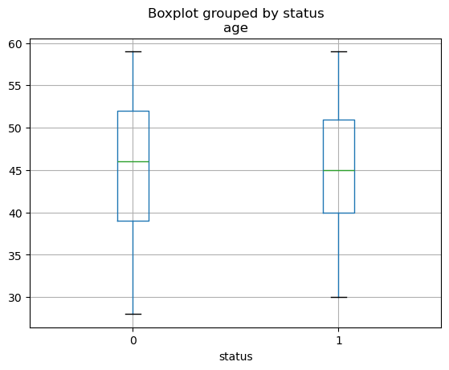

```python
# Plot employee age vs. status levels.
df.boxplot(column='age', by='status')
```

```python
# mean age of employees who stayed in the company
df['age'][df['status']==0].median()
```

```
46.0
```

```python
# mean age of employees who left the company
df['age'][df['status']==1].median()
```

```
45.0
```

> Median age of employees who stayed in the company is 46 years. Median age of employees who left the company is 45 years.

#### 2. Distance from Home vs Status - does time spent commuting affect attrition?

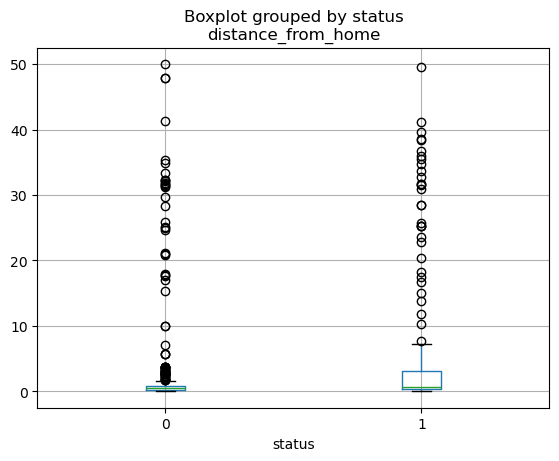

```python
# Plot the average distance from home (in miles) for employees by their status levels in the company.
df.boxplot(column='distance_from_home', by='status')
```

```python
df['distance_from_home'][df['status']==0].mean()
```

```
2.29531007751938
```

```python
df['distance_from_home'][df['status']==1].mean()
```

```
5.964294117647059
```

**Insight:** In terms of average distance from home - employees who have a longer commute tend to leave the company.

> The average distance from home for employees who stayed (status = 0) is 2.3 miles. The average distance from home for employees who left (status = 1) is 5.9 miles. The 2.5x difference between the two groups suggests that those with a longer commute tend to leave the company.

#### 3. Manager satisfaction score vs Status - does employee relation with their manager affect attrition?

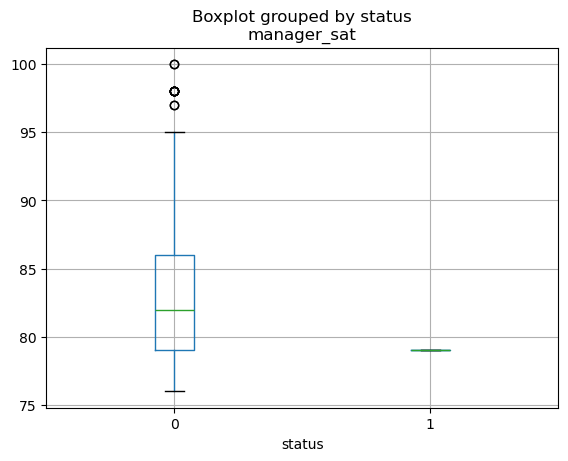

```python
# Plot the average manager satisfaction score which measures how satisfied employees are with their manager.
df.boxplot(column='manager_sat', by='status')
```

```python
# Average Manager Satisfaction score of employees who stayed
df['manager_sat'][df['status']==0].median()
```

```
82.0
```

```python
# Average Manager Satisfaction score of employees who left
df['manager_sat'][df['status']==1].median()
```

```
79.0
```

**Insight:** It seems that employees who rate their manager with a manager satisfaction score of 79 and below, tend to leave the company.

> Employees who rated their manager with a score of 82 and above tend to stay at the company. Employees who rated their manager with a score of 79 and below left the company.

#### 4. Employee Satisfaction vs Status - does employee satisfaction impact attrition?

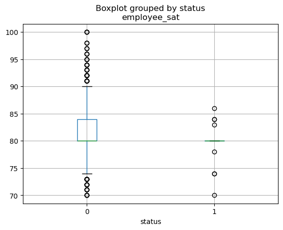

```python
# Plot the employee satisfaction score which measures how satisfied employees are within the company.
df.boxplot(column='employee_sat', by='status')
```

```python
# Average employee satisfaction score of those who stayed in the company.
df['employee_sat'][df['status']==0].mean()
```

```
81.62790697674419
```

```python
# Average employee satisfaction score of those who left the company.
df['employee_sat'][df['status']==1].mean()
```

```
79.95882352941176
```

> The average employee satisfaction score of those who stayed in the company was 81.6 The average employee satisfaction score of those who left the company was 79.96

#### 5. Bonus vs Status - does employee bonus impact attrition?

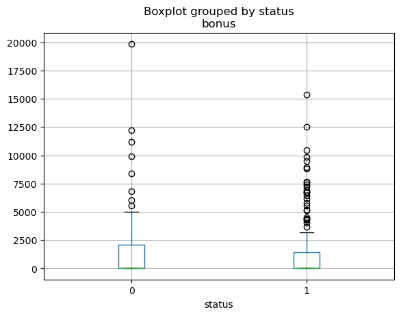

```python
# Plot employee bonus vs. employee status
df.boxplot(column='bonus', by='status')
```

```python
# Average bonus of employees who left
df['bonus'][df['status']==1].mean()
```

```
1374.0411764705882
```

```python
# Average bonus of employees who stayed
df['bonus'][df['status']==0].mean()
```

```
1006.4399224806201
```

> Employees who received a higher bonus (1,374.04) left the company Employees who stayed received a lower bonus (1,006.44) stayed with the company.

#### 6. Number of courses taken vs Status - do employee training courses affect attrition?

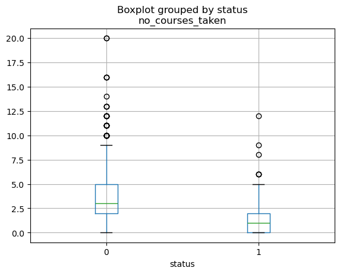

```python
# Plot the number of courses taken vs. Status
df.boxplot(column='no_courses_taken', by='status')
```

```python
# Plot the average number of courses taken by employees who left
df['no_courses_taken'][df['status']==1].median()
```

```
1.0
```

```python
# Plot the average number of courses taken by employees who stayed
df['no_courses_taken'][df['status']==0].median()
```

```
3.0
```

**Insight:** It seems that employee training courses tend to encourage employees to stay in the company. This may be due to employees who feel that building up their skills base will make them likely to get a promotion and a pay raise.

> On average, employees who took 3 or more courses tend to stay in the company. Employees who only participated in 1 course tend to leave the company.

#### 7. Time spent in a position vs Status - does the length of time spent in a position affect attrition?

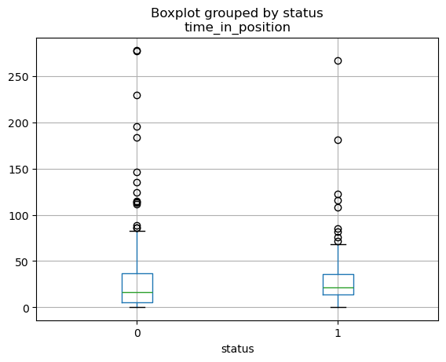

```python
# Plot average time in position (in months) vs. Status
df.boxplot(column='time_in_position', by='status')
```

```python
# Average time in position of employees who left
df['time_in_position'][df['status']==1].median()
```

```
21.5
```

```python
# Average time in position of employees who stayed
df['time_in_position'][df['status']==0].median()
```

```
16.5
```

> The average time spent in a position for employees who left the company was 21.5 months. The average time spent in a position for employees who stayed was 16.5 months. Overall, there was around a 5 month difference in time spent in a position between those who left the company and those who stayed.

#### 8. Percentage Salary Change vs Status - does a pay hike have an effect on attrition?

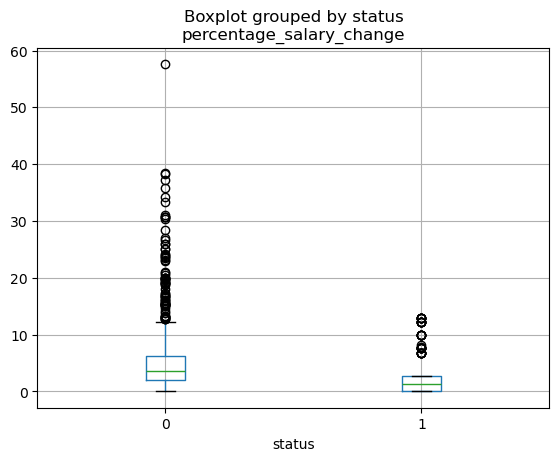

```python
# Plot percentage salary increase vs. Status
df.boxplot(column='percentage_salary_change', by='status')
```

```python
# Average percentage pay hike of employees who left
df['percentage_salary_change'][df['status']==1].mean()
```

```
2.8998591210597175
```

```python
# Average percentage pay hike of employees who stayed
df['percentage_salary_change'][df['status']==0].mean()
```

```
5.88449124991046
```

**Insight:** It seems that percentage salary increases is a significant factor in explaining attrition.

> On average, employees with a smaller pay raise (+2.89%) left the company On average, employees with a larger pay raise (+5.88%) stayed with the company.

#### VI. Validate Significant Variables thru Statistical Testing

- For a variable to be included in the logistic regression model as a predictor variable, it is subjected to a statistical tests to determine whether or not it meets the minimum threshold of 0.05 statistical significance.
- Statisticians use a Chi-Square to test whether two categorical variables are related to each other, i.e., one variable has an effect on the other variable;
- Statisticians use a Two Sample T-test to test whether two variables - a numerical and a categorical variable - are related to each other, i.e., whether one variable has an impact on the other variable.

#### 1. Hypothesis Testing - Chi-Square Test (categorical vs categorical variables)

- We run a chi-square test between 2 categorical variables to see if the two variables are related (or dependent) on each other. If there is no relationship between the two variables, we state that the variables are independent from one another.

#### Conditions for Hypothesis Testing:

> - Each statistical test will have a significance level of 0.05.
> - If the p-value of the chi-square test is > 0.05, **we accept the null hypothesis (H0)** that the variables are independent.
> - If the p-value is below 0.05, **we reject the null hypothesis and accept the alternative hypothesis (H1)** that the two variables are dependent on each other.

> Statisticans have a popular saying:
> - **"If P is low, the null will go"** (reject the null hypothesis); **"if P is high, the null will fly"** (accept the null hypothesis).

```python
# import stats library from python
import scipy.stats as sp
```

### a. Gender vs. Status

- H0: Gender and Status are independent from each other (i.e., gender has no impact on status)
- H1: Gender and Status are dependent on each other (i.e., gender has an impact on status)

```python
# Perform the chi-square test
table = pd.crosstab(df['gender'], df['status'])
sp.chi2_contingency(table)
```

```
Chi2ContingencyResult(statistic=0.02989476143031883, pvalue=0.8627292328103568, dof=1, expected_freq=array([[134.64139942,  44.35860058],
       [381.35860058, 125.64139942]]))
```

> The chi-square test between gender and status has a p-value of 0.863 which is higher than 0.05. This means that we accept the null hypothesis that gender and attrition are both independent from one another, and that gender does not affect attrition.

### b. Service Agreement vs. Status

- H0: there is no relation between service agreement and status (i.e., service agreement plays no role on the decision to leave)
- H1: service agreement and status are related to each other (i.e., service agreement affects employee turnover)

```python
# Run the chi-square test
table = pd.crosstab(df['service_agreement'], df['status'])
sp.chi2_contingency(table)
```

```
Chi2ContingencyResult(statistic=6.72420174117774, pvalue=0.009511328983283338, dof=1, expected_freq=array([[433.25947522, 142.74052478],
       [ 82.74052478,  27.25947522]]))
```

> The chi-square test shows a p-value of 0.01 which is lower than 0.05. We reject the null (H0) and accept the alternative (H1) that not having a service agreement has an impact on employee turnover.

### c. Job Level vs. Status

- H0: job level and status are indepdent of one another (i.e., no relation between job level and the decision to leave)
- H1: job level is related to status (i.e., job level has an effect on attrition)

```python
# Run the chi-square test
table = pd.crosstab(df['job_level'], df['status'])
sp.chi2_contingency(table)
```

```
Chi2ContingencyResult(statistic=2.337844062473902, pvalue=0.6738877352129603, dof=4, expected_freq=array([[265.52186589,  87.47813411],
       [153.44606414,  50.55393586],
       [ 63.93586006,  21.06413994],
       [ 24.82215743,   8.17784257],
       [  8.27405248,   2.72594752]]))
```

> The chi-square test between job level and status has a p-value of 0.674 which is higher than 0.05. We accept the null hypothesis that job level has no effect on the decision to leave.

### d. no_of_promotions vs. Status

- H0: no_of_promotions and status are indepdent of one another (i.e., no relation between the two variables)
- H1: no_of_promotions is related to status (i.e., no_of_promotions has an effect on attrition)

```python
# Run the chi-square test
table = pd.crosstab(df['no_of_promotions'], df['status'])
sp.chi2_contingency(table)
```

```
Chi2ContingencyResult(statistic=16.234810070749838, pvalue=0.03913994369619338, dof=8, expected_freq=array([[3.55784257e+02, 1.17215743e+02],
       [7.82274052e+01, 2.57725948e+01],
       [4.43790087e+01, 1.46209913e+01],
       [1.65481050e+01, 5.45189504e+00],
       [1.27871720e+01, 4.21282799e+00],
       [4.51311953e+00, 1.48688047e+00],
       [1.50437318e+00, 4.95626822e-01],
       [1.50437318e+00, 4.95626822e-01],
       [7.52186589e-01, 2.47813411e-01]]))
```

> The chi-square test shows a p-value of 0.04 which is slightly lower than 0.05. This means that we reject H0 and accept H1 that the number of promotions has an affect on attrition.

### e. risk_of_attrition vs. Status

- H0: risk_of_attrition and status are indepdent of one another (i.e., no relation between the two variables)
- H1: risk_of_attrition is related to status (i.e., risk_of_attrition has an effect on attrition)

```python
# Run the chi-square test
table = pd.crosstab(df['risk_of_attrition'], df['status'])
sp.chi2_contingency(table)
```

```
Chi2ContingencyResult(statistic=56.128165504639895, pvalue=3.944526151206098e-12, dof=3, expected_freq=array([[ 25.57434402,   8.42565598],
       [226.40816327,  74.59183673],
       [214.37317784,  70.62682216],
       [ 49.64431487,  16.35568513]]))
```

> The chi-square test shows a p-value of 0.0 which is lower than 0.05. We reject H0 and accept H1 that the risk of attrition has an effect on attrition.

### f. potential_rating vs. Status

- H0: potential_rating and status are indepdent of one another (i.e., no relation between the two variables)
- H1: potential_rating affects status (i.e., potential_rating plays a role on attrition)

```python
# Run the chi-square test
table = pd.crosstab(df['potential_rating'], df['status'])
sp.chi2_contingency(table)
```

```
Chi2ContingencyResult(statistic=26.966061641155147, pvalue=2.019545165087339e-05, dof=4, expected_freq=array([[ 25.57434402,   8.42565598],
       [ 28.58309038,   9.41690962],
       [169.24198251,  55.75801749],
       [147.42857143,  48.57142857],
       [145.17201166,  47.82798834]]))
```

> The chi-square test shows a p-value of 0.0 which is lower than 0.05. We reject the null H0 and accept the alternative H1 that potential_rating does have an affect on attrition.

### g. awards vs. Status

- H0: awards and status are indepdent of one another (i.e., no relation between the two variables)
- H1: awards has an effect on attrition

```python
# Run the chi-square test
table = pd.crosstab(df['awards'], df['status'])
sp.chi2_contingency(table)
```

```
Chi2ContingencyResult(statistic=11.074199327587491, pvalue=0.000875372103862832, dof=1, expected_freq=array([[470.86880466, 155.13119534],
       [ 45.13119534,  14.86880466]]))
```

> The chi-square test shows a p-value of 0.0 which is lower than 0.05. We reject the null hypothesis H0 and accept the alternative hypothesis H1 that employee awards can have an effect on attrition. Recognizing an employee's achievement(s) could induce loyalty to the company.

### h. sign-on bonus vs. Status

- H0: A sign-on bonus has no effect on attrition
- H1: A sign-on bonus affects attrition

```python
# Run the chi-square test

table = pd.crosstab(df['signon'], df['status'])
sp.chi2_contingency(table)
```

```
Chi2ContingencyResult(statistic=0.7449395397968127, pvalue=0.3880831472807692, dof=1, expected_freq=array([[507.72594752, 167.27405248],
       [  8.27405248,   2.72594752]]))
```

> The chi-square p-value of 0.388 is higher than 0.05; we accept the null hypothesis H0 that a sign-on bonus has no affect on attrition.

### i. Var_rating vs. Status

- H0: A change in the Var_rating (employee performance rating) has no effect on attrition.
- H1: The change in Var_rating has an impact on attrition.

```python
# Run the chi-square test

table = pd.crosstab(df['Var_rating'], df['status'])
sp.chi2_contingency(table)
```

```
Chi2ContingencyResult(statistic=15.646652000534539, pvalue=0.0035318724704160947, dof=4, expected_freq=array([[1.20349854e+01, 3.96501458e+00],
       [9.77842566e+01, 3.22157434e+01],
       [3.10653061e+02, 1.02346939e+02],
       [9.47755102e+01, 3.12244898e+01],
       [7.52186589e-01, 2.47813411e-01]]))
```

> The chi-square p-value of 0.00 is less than 0.05 which indicates that a change in the Var_rating has an effect on attrition.

#### 2. Hypothesis Testing - Welch's Two Sample T-test (numerical vs categorical variables)

- We run a Welch two Sample T-test between a numerical variable and a categorical variable to see if the two variables are related (or dependent) to each other. If no relationship exists between the variables, then we accept the null hypothesis H0 which states that the two variables are independent from one another.

#### Before running the two sample t-Test, we first check if the sample distributions are normally distributed and have equal variances.

- The sample distribution must be a normal distribution with equal variances.
- We view the distribution of the sample data by plotting a histogram and seeing if it conforms to the normal bell distribution curve (i.e., gaussian distribution);
- We run the **Shapiro-Wilk test** for normality on each sample data. If p-value > 0.05, we accept the null hypothesis H0 and assume a normal distribution for the sample data.
- We run **Levene's Test for Equality of Variances**. If p-value > 0.05, we accept the null hypothesis H0, which states that the sample variances are roughly equal or not significantly different from each other.

#### After checking for normality and equal variances among the sample distributions, we run a two sample T-test. If the sample distribution is normal with equal variances, we run a **parametric test.** If the sample distribution is not normally distributed and has unequal variances, we run a **non-parametric test.**

#### All of our sample data has a non-normal distribution with unequal variances. We will therefore run a non-parametric t-test called the Welch's two sample T-test:

- We set the significance level to 0.05 for the Welch's two sample T-test.
- If the p-value of the Welch's t-test is > 0.05, **we accept the null hypothesis (H0)** that the variables are independent.
- If the p-value of the Welch's t-test is below 0.05, **we reject the null hypothesis and accept the alternative hypothesis (H1)** that the two variables are dependent on each other.

#### A. Check the following sample data for normal distribution and equal variances:

- 1. age,
- 2. distance from home,
- 3. manager satisfaction,
- 4. employee satisfaction,
- 5. bonus,
- 6. number of courses taken,
- 7. time in position and
- 8. percentage salary change

#### 1. Import stats libraries from Python

```python
import numpy as np
import scipy.stats as stats
from scipy.stats import shapiro
from scipy.stats import levene
import matplotlib.pyplot as plt
import statsmodels.api as sm
```

#### 2. Plot a histogram and examine the shape of the distribution; also check for equlity of variances.

```
1.17078737103221
```

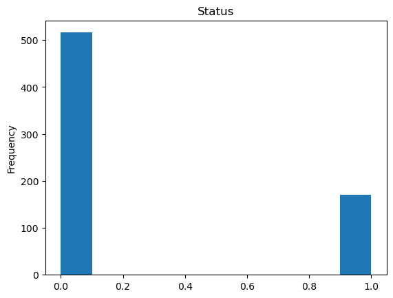

```python
# plot a histogram for status
df['status'].plot.hist()
plt.title('Status')
plt.figure(figsize=(0,0))
df['status'].skew()
```

```
-0.053474199890542584
```

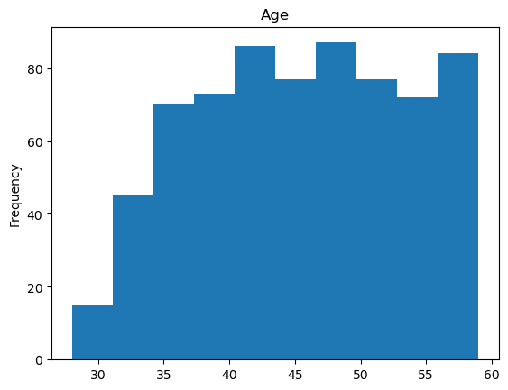

```python
# plot a histogram for age
df['age'].plot.hist()
plt.title('Age')
plt.figure(figsize=(0,0))
df['age'].skew()
```

```
3.391949043297557
```

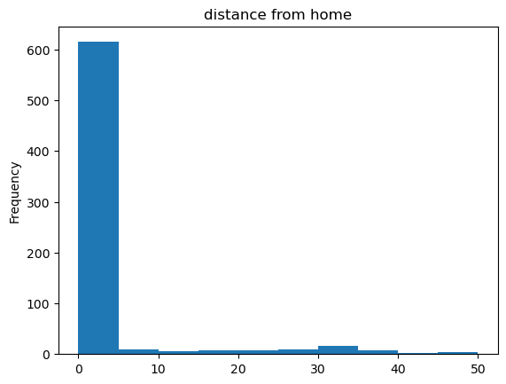

```python
# plot a histogram for distance from home
df['distance_from_home'].plot.hist()
plt.title('distance from home')
plt.figure(figsize=(0,0))
df['distance_from_home'].skew()
```

```
1.2416158547092389
```

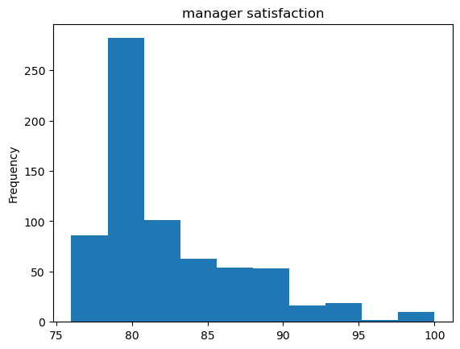

```python
# plot a histogram for manager satisfaction
df['manager_sat'].plot.hist()
plt.title('manager satisfaction')
plt.figure(figsize=(0,0))
df['manager_sat'].skew()
```

```
1.1886925569711662
```

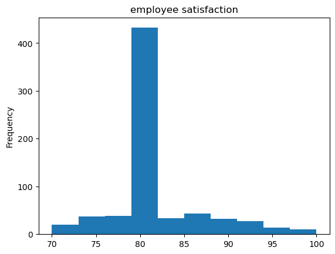

```python
# plot a histogram for employee satisfaction
df['employee_sat'].plot.hist()
plt.title('employee satisfaction')
plt.figure(figsize=(0,0))
df['employee_sat'].skew()
```

```
3.221230554544314
```

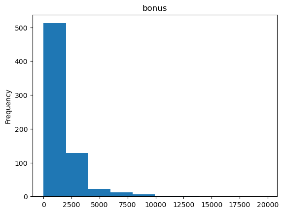

```python
# plot a histogram for bonus
df['bonus'].plot.hist()
plt.title('bonus')
plt.figure(figsize=(0,0))
df['bonus'].skew()
```

```
1.7056362855376992
```

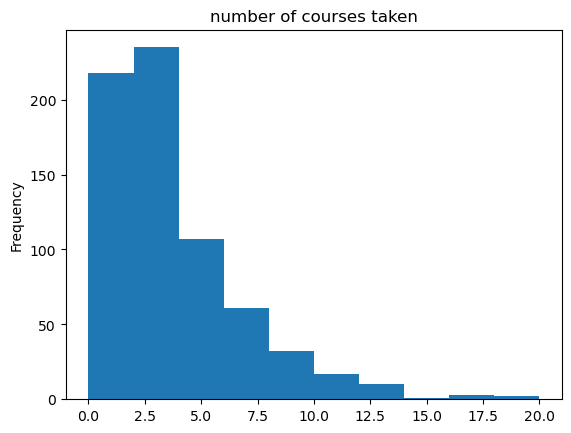

```python
# plot a histogram for number of courses taken
df['no_courses_taken'].plot.hist()
plt.title('number of courses taken')
plt.figure(figsize=(0,0))
df['no_courses_taken'].skew()
```

```
3.6532759709327496
```

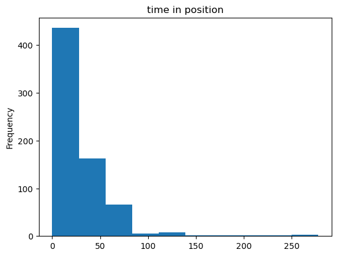

```python
# plot a histogram for time in position
df['time_in_position'].plot.hist()
plt.title('time in position')
plt.figure(figsize=(0,0))
df['time_in_position'].skew()
```

```
2.713469121367676
```

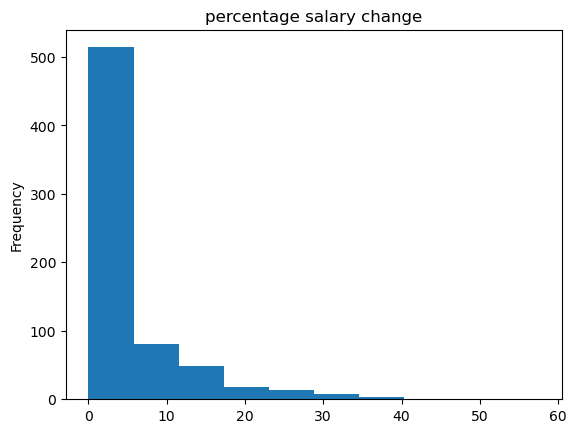

```python
# plot a histogram for percentage salary change
df['percentage_salary_change'].plot.hist()
plt.title('percentage salary change')
plt.figure(figsize=(0,0))
df['percentage_salary_change'].skew()
```

#### 3. Run the Shapiro-Wilk test to validate that the sample data distribution is non-normal. If p-value > 0.05, we accept the null hypothesis H0 and assume a normal distribution for the sample data.

- H0: your sample data is normally distributed
- H1: your sample data is not normally distributed

```python
# Perform Shapiro-Wilk test on dependent and independent variables
print("status: " + str(shapiro(df['status'])))
print("age: " + str(shapiro(df['age'])))
print("distance_from_home: " + str(shapiro(df['distance_from_home'])))
print("manager_sat: " + str(shapiro(df['manager_sat'])))
print("employee_sat: " + str(shapiro(df['employee_sat'])))
print("bonus: " + str(shapiro(df['bonus'])))
print("no_courses_taken: " + str(shapiro(df['no_courses_taken'])))
print("time_in_position: " + str(shapiro(df['time_in_position'])))
print("percentage_salary_change: " + str(shapiro(df['percentage_salary_change'])))
```

```
status: ShapiroResult(statistic=0.5365954238220977, pvalue=5.764159811640837e-39)
age: ShapiroResult(statistic=0.9714786973458627, pvalue=2.67083652404741e-10)
distance_from_home: ShapiroResult(statistic=0.3979547807196768, pvalue=1.1182421868161874e-42)
manager_sat: ShapiroResult(statistic=0.8493535882761062, pvalue=5.038166960431522e-25)
employee_sat: ShapiroResult(statistic=0.7939494453596339, pvalue=1.3854712946656962e-28)
bonus: ShapiroResult(statistic=0.5777457099419415, pvalue=1.0898064782731079e-37)
no_courses_taken: ShapiroResult(statistic=0.8371546046784832, pvalue=6.925346726564255e-26)
time_in_position: ShapiroResult(statistic=0.6852648528077856, pvalue=8.431602421096847e-34)
percentage_salary_change: ShapiroResult(statistic=0.6972662895935882, pvalue=2.6531182125707246e-33)
```

#### 4. Run Levene's Test for Equality of Variances on the sample data.

#### Perform Levene's Test for Equality of Variances. If p-value > 0.05: we accept H0, which states that the sample variances are roughly equal or not significantly different. If p-value < 0.05: we reject H0, indicating that there are significant differences in variances among the groups.

- **H0:** sample variances among the sample groups are roughly the same
- **H1:** there are significant differences in variances among the sample groups

##### Note: for the Levene's test, we set the center parameter = "median" because this is the ideal parameter for skewed distributions. The median setting reduces outlier influence, enhancing robustness in non-normal data.

```python
# Run Levene's test on 'status' and 'age'
print(stats.levene(df['status'], df['age'], center='median'))
```

```
LeveneResult(statistic=1676.4572620530414, pvalue=5.210692627408231e-240)
```

```python
# Run Levene's test on 'status' and 'distance from home'
print(stats.levene(df['status'], df['distance_from_home'], center='median'))
```

```
LeveneResult(statistic=71.7755947335811, pvalue=6.134799824787087e-17)
```

```python
# Run Levene's test on 'status' and 'manager satisfaction'
print(stats.levene(df['status'], df['manager_sat'], center='median'))
```

```
LeveneResult(statistic=385.548538447294, pvalue=7.804441197665956e-76)
```

```python
# Run Levene's test on 'status' and 'employee satisfaction'
print(stats.levene(df['status'], df['employee_sat'], center='median'))
```

```
LeveneResult(statistic=225.185069877351, pvalue=3.053040938440208e-47)
```

```python
# Run Levene's test on 'status' and 'bonus'
print(stats.levene(df['status'], df['bonus'], center='median'))
```

```
LeveneResult(statistic=182.38240411444556, pvalue=4.126990285894861e-39)
```

```python
# Run Levene's test on 'status' and 'number of courses taken'
print(stats.levene(df['status'], df['no_courses_taken'], center='median'))
```

```
LeveneResult(statistic=367.9051541839984, pvalue=8.039045487025113e-73)
```

```python
# Run Levene's test on 'status' and 'time in position'
print(stats.levene(df['status'], df['time_in_position'], center='median'))
```

```
LeveneResult(statistic=347.4331107315333, pvalue=2.7553032997168897e-69)
```

```python
# Run Levene's test on 'status' and 'percentage salary change'
print(stats.levene(df['status'], df['percentage_salary_change'], center='median'))
```

```
LeveneResult(statistic=266.2408704588023, pvalue=7.841596713629014e-55)
```

> All p-values from Levene's test were less than the 0.05 significance level. This indicates unequal variances among all the sample groups.

#### 5. Run the Welch's T-test: a non-parametric test to validate whether various predictor variables have an effect on attrition.

```python
# Run a T-test on age vs status
stats.ttest_ind(df['age'],df['status'], equal_var=False)
```

```
TtestResult(statistic=152.89506180745045, pvalue=0.0, df=689.2751648323166)
```

> T-test shows the p-value is less than 0.05, which is evidence to suggest that age has an impact on attrition.

```python
# Run a T-test on distance from home vs status
stats.ttest_ind(df['distance_from_home'],df['status'], equal_var=False)
```

```
TtestResult(statistic=9.161721094837706, pvalue=5.770192156985222e-19, df=688.5887837076955)
```

> T-test shows the p-value is less than 0.05, this is evidence to show that distance from home is a significant variable.

```python
# Run a T-test on employee satisfaction vs status
stats.ttest_ind(df['manager_sat'],df['status'], equal_var=False)
```

```
TtestResult(statistic=441.7197483777288, pvalue=0.0, df=695.922172941696)
```

> The T-test p-value is less than 0.05, this suggests that manager satisfaction has an effect on attrition.

```python
# Run a T-test on employee satisfaction vs status
stats.ttest_ind(df['employee_sat'],df['status'], equal_var=False)
```

```
TtestResult(statistic=422.0585696487064, pvalue=0.0, df=695.2050354284108)
```

> T-test p-value is less than 0.05 which indicates that employee satisfaction has an impact on attrition.

```python
# Run a T-test on bonus vs status
stats.ttest_ind(df['bonus'],df['status'], equal_var=False)
```

```
TtestResult(statistic=13.504902965754532, pvalue=5.094418125404788e-37, df=685.0000564704935)
```

> T-test p-value is less than 0.05 meaning bonus has an effect on attrition.

```python
# Run a T-test on number of courses taken vs status
stats.ttest_ind(df['no_courses_taken'],df['status'], equal_var=False)
```

```
TtestResult(statistic=25.399058817388024, pvalue=7.925930338923164e-102, df=712.2430694711942)
```

> T-test p-value is less than 0.05, which is sufficient evidence that number of courses taken is a significant variable.

```python
# Run a T-test on time in position vs status
stats.ttest_ind(df['time_in_position'],df['status'], equal_var=False)
```

```
TtestResult(statistic=22.618312114518137, pvalue=4.8775197877367116e-85, df=685.2597881154447)
```

> The p-value is less than 0.05, which means there is evidence to show that time in position is a significant variable.

```python
# Run a T-test on percentage salary change vs status
stats.ttest_ind(df['percentage_salary_change'],df['status'], equal_var=False)
```

```
TtestResult(statistic=18.772049943241274, pvalue=7.78082343728678e-64, df=690.5000736666108)
```

> The p-value is less than 0.05 indicating sufficient evidence that percentage salary change has an impact on attrition.